# Praca domowa 2

## Pediatric Chest X-Ray Pneumonia

### Informacje o danych

- **Rozszerzenie zdjęć:** JPEG
- **Sprzęt, na którym wykonano badania:** brak informacji
- **Format annotacji:** przydzielenie plików do odpowiednich folderów
- **Płaszczyzny zdjęć:** rzut z przodu
- **Nazwy klas:** foldery nazwane *NORMAL* i *PNEUMONIA*
- **Kontrast:** brak
- **Data wykonania zdjęć:** brak informacji
- **Slice thickness:** nie dotyczy
- **Kształt zdjęć:** różny (patrz: kod poniżej)
- **Podział na zbiór testowy i treningowy:** tak
- **Kraj pochodzenia zdjęć:** brak informacji

### Analiza metadanych

- **Metadane**: brak
- **Wiek:** brak informacji
- **Pomieszanie dzieci i dorosłych:** baza danych składa się wyłącznie ze zdjęć dzieci
- **Braki w metadanych:** brak
- **Mierzenie poważności zmian:** brak
- **Pacjenci covidowi:** nie wiadomo
- **Dane usunięte**: wszystkie

### Dane jakościowe

- **Jakość zdjęć:** zdjęcia są podobnej, dobrej jakości, choć są różnice w jakości
- **Czy zdjęcia między klasami i między bazami danych się różnią czymś poza płucami?** Nie
- **Ostrość/rozmazanie:** są rozmazania chcarakterystyczne dla zdjęć RTG, ale nie ma zdjęć przesadnie rozmazanych
- **Artefakty:** brak
- **Aparatura medyczna:** brak
- **Litery na obrazach:** R, A-P
- **Czy mamy podstawy sądzić, że np. zaznaczono tylko jedną zmianę/chorobę zamiast wszystkich?** Nie zaznaczono żadnych zmian, całe zdjęcia są klasyfikowane
- **Dane osobowe:** brak
- **Kanałowość:** wszystkie zdjęcia są jednokanałowe
- **Rozmiary zdjęć:** (patrz: kod poniżej)
- **Różnice pomiędzy zbiorem testowym i treningowym:** nie zauważyłem żadnych
- **Jakość danych (w skali 1-5):** 4
- **Skale pewności annotacji:** brak

### Analiza obrazów

- **Przynależność do klasy po histogramie:** (patrz: kod poniżej)
- **Dane pacjenta z różnych dni:** brak
- **Wartości pikseli w obrazach:** 0-1
- **Zdjęcia z dziwnie przesuniętym histogramem:** brak
- **Zdjęcia nie na środku:** brak
- **Wszystkie zdjęcia w pionie:** tak

### Kody:

```python
from os import listdir
from os.path import isfile, join
path = '/Users/deregowskis/Desktop/studies/WB/Pediatric Chest X-Ray Pneumonia'
all_files = []
train_pneumonia = [f for f in listdir(path+'/'+'train/PNEUMONIA') if isfile(join(path+'/'+'train/PNEUMONIA', f))]
for file in train_pneumonia:
    all_files.append(path+'/'+'train/PNEUMONIA/'+file)
train_normal = [f for f in listdir(path+'/'+'train/NORMAL') if isfile(join(path+'/'+'train/NORMAL', f))]
for file in train_normal:
    all_files.append(path+'/'+'train/NORMAL/'+file)
test_pneumonia = [f for f in listdir(path+'/'+'test/PNEUMONIA') if isfile(join(path+'/'+'test/PNEUMONIA', f))]
for file in test_pneumonia:
    all_files.append(path+'/'+'test/PNEUMONIA/'+file)
test_normal = [f for f in listdir(path+'/'+'test/NORMAL') if isfile(join(path+'/'+'test/NORMAL', f))]
for file in test_normal:
    all_files.append(path+'/'+'test/NORMAL/'+file)
```

```python
from PIL import Image

width = []
height = []

for file in all_files:
    width.append(Image.open(file).size[0])
    height.append(Image.open(file).size[1])
```

```
array([[<AxesSubplot:xlabel='width', ylabel='width'>,
        <AxesSubplot:xlabel='height', ylabel='width'>],
       [<AxesSubplot:xlabel='width', ylabel='height'>,
        <AxesSubplot:xlabel='height', ylabel='height'>]], dtype=object)
```

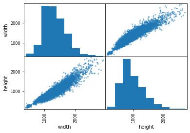

```python
import pandas as pd
pneumonia_dataframe = pd.DataFrame({'width':width,'height':height})
plot = pd.plotting.scatter_matrix(pneumonia_dataframe)
plot
```

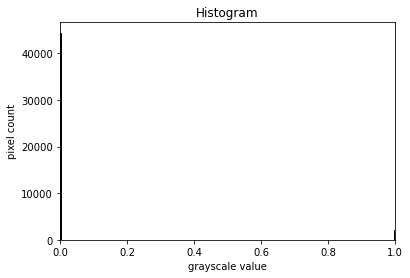

```python
plt.figure()
plt.title("Histogram")
plt.xlabel("grayscale value")
plt.ylabel("pixel count")
plt.xlim([0.0, 1.0])
image = plt.imread(path+'/train/PNEUMONIA/'+train_pneumonia[1])
plt.hist(image.ravel(), bins=256, range=(0.0, 1.0), fc='k', ec='k')
plt.show()
```

Rozkład jest 0-1, więc histogram na nic się nie zda. Zbadajmy proporcję białych i czarnych pikseli na zdjęciach z klasy normal i pneumonia dla zbioru treningowego:

```python
from tqdm import trange
normal = []
pneumonia = []
for i in trange(len(train_normal)):
    image = plt.imread(path+'/train/NORMAL/'+train_normal[i])
    ar = image.ravel().tolist()
    normal.append(ar.count(0)/len(ar))
for i in trange(len(train_pneumonia)):
    image = plt.imread(path+'/train/PNEUMONIA/'+train_pneumonia[i])
    ar = image.ravel().tolist()
    pneumonia.append(ar.count(0)/len(ar))
```

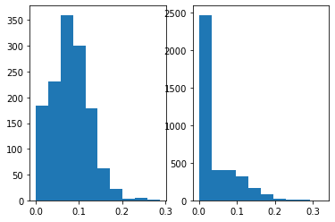

```python
plt.subplot(1,2,1)
plt.hist(normal)
plt.subplot(1,2,2)
plt.hist(pneumonia)
plt.show()
```

```python
from tqdm import trange
normal_x_size = []
normal_y_size = []
pneumonia_x_size = []
pneumonia_y_size = []
for i in trange(len(train_normal)):
    image = plt.imread(path+'/train/NORMAL/'+train_normal[i])
    normal_x_size.append(image.shape[0])
    normal_y_size.append(image.shape[1])
for i in trange(len(train_pneumonia)):
    image = plt.imread(path+'/train/PNEUMONIA/'+train_pneumonia[i])
    pneumonia_x_size.append(image.shape[0])
    pneumonia_y_size.append(image.shape[1])
```

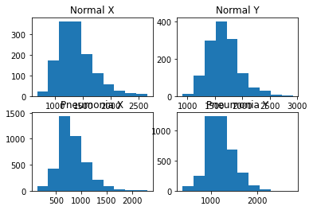

```python
plt.subplot(2,2,1)
plt.hist(normal_x_size)
plt.title("Normal X")
plt.subplot(2,2,3)
plt.hist(pneumonia_x_size)
plt.title("Pneumonia X")
plt.subplot(2,2,2)
plt.hist(normal_y_size)
plt.title("Normal Y")
plt.subplot(2,2,4)
plt.hist(pneumonia_y_size)
plt.title("Pneumonia Y")
plt.show()
```